# Studio sulla comunità LGBT Europea per il corso di Fondamenti di Scienza dei Dati

Davide Strazzi 144046

2022-07-18

## Database analizzati

Il progetto è partito trovando 3 file csv su Kaggle.com riguardanti i risultati di un questionario proposoto alle persone della comunità LGBT in Europa.  
I file sono separati poichè ogni questionario ha dati riguardo aspetti diversi:

1. *Daily*: pone domande sulla qualità della vita di tutti i giorni ed è anche il database con numero più alto di dati contenuti.
2. *Discrimination*: pone domande sulla discriminazione che le persone LGBT hanno vissuto nella loro vita.
3. *Transgender*: questionario specifico per persone Transgender.

## Dati contenuti nei file

Ognuno di questi file contiene 7 colonne di dati:

1. **CountryCode**: Paese d’origine del soggetto.
2. **subset**: Identità del soggetto (Lesbian, Gay, Bisexual women, Bisexual men, Transgender).
3. **question_code**: Codice identificativo univoco della domanda posta.
4. **question_label**: Domanda posta ai soggetti.
5. **answer**: Risposta data dai soggetti alla domanda posta.
6. **percentage**: percentuale di soggetti che appartengono all’osservazione.
7. **notes**: note aggiuntive dell’autore, campo principalmente vuoto.

## Prima pulizia

Una delle colonne di dati è eliminabile: notes non influisce sui dati raccolti o sull’analisi che faremo.

**Nota** su question_code e question_label: per correttezza avrei dovuto unire le due colonne in una singola in quanto entrambe rappresentano lo stesso dato. Nel progetto talvolta le ho mantenute separate per comodità di analisi.

## Selezione domande del questionario

Tutto il progetto si applica su dati di natura qualitativa, in certi casi le risposte del questionario sono quantificabili, in altri sono perlomeno categorizzabili.

Tutte le domande che risulteranno ininfluenti al nostro studio o che semplicemente prevedono risposte di natura aperta e personale sono state eliminate dal Dataset.

Finita la pulizia dei dati ci ritroveremo con osservazioni del Dataset di questo tipo:

```
##   CountryCode      subset question_code answer percentage
## 1       Italy Transgender           tr1    Yes         24
```

## Domande

Una volta pulito il Dataset possiamo iniziare a farci delle domande alle quali il Dataset potrà rispondere.

Purtroppo essendo il Dataset così vasto e così ben organizzato, la maggior parte delle domande che possiamo porci hanno risposte facilmente individuabili.

Possiamo quindi porci due quesiti principali generali per i quali le risposte non siano ovvie e dove l’analisi sia un pò più complessa:

**1**. Qual’è il paese dove la comunità LGBT vive meglio / peggio?

**2**. Dati generali sui subset della comunità LGBT ed eventuali correlazioni tra i dati.

Come ultima analisi del progetto risponderemo a domande più semplici con risposte facilmente individuabili dal Dataset.

## Nota aggiuntiva sulle domande poste:

La differenza di dimensione dei file csv è causata sia dalla quantità di domande poste, sia dal numero di individui sottoposti al questionario. Ogni file csv ha inoltre una popolazione differente e per questo motivo non possono essere analizzate contemporaneamente domande provenienti da due csv diversi. Possiamo utilizare le domande tratte da un file csv per creare un’ipotesi per confrontarla e verficarne la veridicità con domande similari presenti in altri file csv.

## Domanda 1: Qual’è il paese dove la comunità LGBT vive meglio / peggio?

Useremo il csv Daily per formulare un ipotesi e il csv Discrimination potrà confermare o smentire tale ipotesi.

La parte più veloce da analizzare è individuare il paese con le **condizioni migliori** poichè le domande pertinenti presenti nei Dataset sono solo 4.

Per ogni subset possiamo stabilire il paese nel quale la percentuale di risposte “positive” sia la più alta; raggruppando tutti i dati e ordinandoli in base al numero di volte per il quale un paese viene indicato come “migliore”, creiamo la seguente tabella:

```
## # A tibble: 4 × 2
##   CountryCode count
##   <chr>       <int>
## 1 Netherlands     8
## 2 Belgium         3
## 3 Denmark         3
## 4 Sweden          1
```

Stando ai dati possiamo ipotizzare che l’Olanda sia il paese in cui la comunità LGBT vive meglio.

Possiamo dimostrare questa ipotesi individuando i paesi in cui i casi di discriminazione siano i più bassi (maggior percentuale media di risposte “No” alle domande sulla discriminazione).

```
## # A tibble: 29 × 2
##    CountryCode    media
##    <chr>          <dbl>
##  1 Netherlands     78.7
##  2 Denmark         78.7
##  3 Belgium         74.9
##  4 Finland         74.7
##  5 Sweden          74.4
##  6 Czech Republic  73.9
##  7 Malta           73.3
##  8 Slovenia        73.2
##  9 Austria         72.3
## 10 Germany         72.0
## # … with 19 more rows
```

Tramite l’analisi su Discrimination troviamo l’Olanda tra i paesi con percentuale più bassa di discriminazioni.

Abbiamo quindi conferma che l’Olanda risulti essere il paese con le condizioni di vita per la comunità LGBT più favorevoli.

Per quanto riguarda lo studio del paese con le **condizioni peggiori**, all’analisi invece occore un maggior approfondimento in quanto le domande poste sulla discriminazione sono in un numero maggiore rispetto alla precedente analisi e poste con formulazioni differenti.

```
## # A tibble: 7 × 2
##   CountryCode count
##   <chr>       <int>
## 1 Lithuania      11
## 2 Croatia         9
## 3 Bulgaria        8
## 4 Cyprus          6
## 5 Italy           4
## 6 Romania         1
## 7 Spain           1
```

Analizzando dunque i dati di Daily ipotizziamo che la Lituania abbia la condizione di vita peggiore in Europa per la comunità LGBT.

Possiamo verificare questa ipotesi calcolando la percentuale di persone che hanno vissuto discriminazioni nel proprio paese. A ipotesi corretta ci aspettiamo di trovare tra le percentuali più alte la Lituania.

```
## # A tibble: 29 × 2
##    CountryCode    media
##    <chr>          <dbl>
##  1 Lithuania       20.7
##  2 Cyprus          20.3
##  3 Romania         18.8
##  4 Croatia         18.4
##  5 Latvia          18.0
##  6 Ireland         17.2
##  7 United Kingdom  16.7
##  8 Greece          16.5
##  9 Poland          16.4
## 10 Bulgaria        16.1
## # … with 19 more rows
```

La risposta si può trovare analizzando una domanda posta nel questionario: “Thinking about the most recent incident of discrimination, did you or anyone else report it anywhere?”. Filtrando le risposte “No” a questa domanda compaiono i paesi mancanti dalla prima tabella, avendo questi le percentuali più alte di casi di discriminazione non riportati.

```
## # A tibble: 29 × 2
##    CountryCode    media
##    <chr>          <dbl>
##  1 Latvia          97
##  2 Slovenia        96.5
##  3 Cyprus          95
##  4 Poland          95
##  5 Estonia         93.5
##  6 Czech Republic  92.6
##  7 Lithuania       92.6
##  8 Sweden          92.2
##  9 Croatia         92
## 10 Denmark         92
## # … with 19 more rows
```

## Risposta 1:

I dati quindi suggeriscono che la Lituania sia il paese dove la condizione della comunità LGBT sia la peggiore in Europa.

Mentre l’Olanda è il paese dove la condizione della comunità LGBT è la migliore in Europa.

## Domanda 2: Dati generali sui subset della comunità LGBT ed eventuali correlazioni tra i dati

Vogliamo ora analizzare il livello di soddisfazione medio, livello di openness medio e percezione della discriminazione verso il proprio subset medio di tutte le categorie della comunità LGBT.

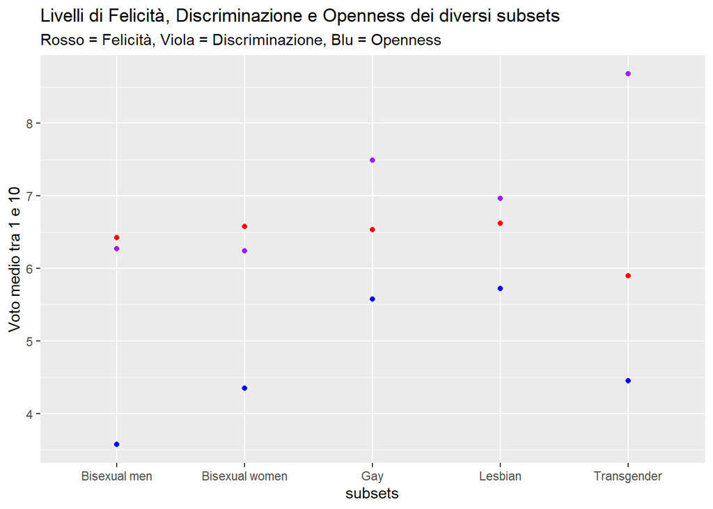

Una conclusione interessante che ci propone questo grafico è che sembra esserci una correlazione tra i dati: livelli di openness bassi e discriminazione alti portano ad una bassa felicità media degli individui.

Testando con la funzione cor() si può trovare correlazione negativa sulla discriminazione e appena sopra lo 0 con openness.

A livello umanistico è facile trovare motivazioni per cui il livello di openness e discriminazione possano influenzare la felicità media della comunità LGBT, ma a livello matematico questa correlazione non esiste o è minima.

Attribuisco questa discordanza alla configurazione dei dati nel Dataset: la colonna percentage del dataset aiuta l’analisi in molti casi ma preclude l’individuazione di correlazioni. Non siamo a conoscenza di tutte le risposte di un soggetto singolo alle domande ma solo per ogni singola domanda il numero degli individui che hanno risposto nello stesso modo.

## Domanda Veloce: Cosa può cambiare l’Italia per migliorare la condizione delle persone LGBT?

Cercando il paese con le condizioni peggiori nella lista ha avuto qualche menzione anche l’Italia. Andiamo quindi ad analizzare quale sia il pensiero della comunità LGBT per migliorare la propria condizione in Italia.

```
## # A tibble: 9 × 2
##   Miglioramenti                                                      Percentuale
##   <chr>                                                                    <dbl>
## 1 Riconoscimento di relazioni dello stesso sesso nell'Unione Europea        86.2
## 2 La possibilità di sposarsi                                                78.5
## 3 Misure implementate nelle scuole per il rispetto                          77.8
## 4 Miglior accettazione da parte di leader religiosi                         77.5
## 5 Autorità nazionali che supportano i diritti LGBT                          75
## 6 Addestramento di pubblici ufficiali sui diritti LGBT                      67.5
## 7 Regole anti-discriminazione sul posto di lavoro                           61.8
## 8 Figure pubbliche che supportano apertamente la comunità                   61.5
## 9 La possibilità di adottare                                                53.2
```

Come vediamo dalla tabella il riconoscimento a livello Europeo è il desiderio più comune della comunità LGBT mentre al secondo posto troviamo la legalità del matrimonio.

**Nota**: Per quanto riguarda questo risultato dev’essere tenuta in cosiderazione la data a cui i soggetti sono stati sottoposti a questo questionario, che è quella dell’anno 2012, mentre la legalizzazione del matrimonio gay in Italia è avvenuta in data successiva(26 maggio 2020).

## Risposta:

Oltre al primo risultato che implica modifiche a livello Europeo e il secondo risultato, già ottenuto, i prossimi passi da compiere sono quelli di migliorare la condizione dei ragazzi LGBT nelle scuole e migliorare il supporto che la chiesa e la religione danno alla comunità LGBT.

## Domanda Veloce: qual’è il paese in cui le persone Transgender nascondono di più la loro identità?

```
##       CountryCode percentage
## 1       Lithuania         52
## 2          Latvia         50
## 3          Poland         47
## 4         Romania         44
## 5         Ireland         43
## 6        Bulgaria         42
## 7         Hungary         40
## 8          France         36
## 9        Slovakia         35
## 10 United Kingdom         35
## 11         Greece         34
## 12       Portugal         34
## 13        Estonia         33
## 14        Average         32
## 15         Sweden         30
## 16        Austria         29
## 17        Germany         29
## 18       Slovenia         28
## 19        Belgium         27
## 20        Finland         27
## 21        Croatia         27
## 22    Netherlands         25
## 23        Denmark         24
## 24          Spain         24
## 25     Luxembourg         24
## 26 Czech Republic         22
## 27          Italy         21
## 28         Cyprus         20
## 29          Malta         NA
```

## Risposta:

Il paese in cui le persone Transgender nascondo maggiormente la loro identità è prevedibilmente la Lituania, lo stesso paese che risultatava essere il peggiore riguardo le condizioni della comunità LGBT.

Si può anche notare che altri paesi nominati come “peggiori” abbiano anche un’alta percentuale di persone Transgender che nascondono la propria identità.

## Domanda Veloce: quale modifica può migliorare in modo più efficace la condizione delle persone Transgender?

```
## # A tibble: 8 × 2
##   Miglioramenti                                                      Percentuale
##   <chr>                                                                    <dbl>
## 1 Addestramento di pubblici ufficiali sui diritti Trans                     59.0
## 2 Misure implementate nelle scuole per il rispetto                          58.4
## 3 Autorità nazionali che supportano i diritti Trans                         55.1
## 4 Miglior accettazione da parte di leader religiosi                         55.0
## 5 Regole anti-discriminazione sul posto di lavoro                           54.5
## 6 Figure pubbliche che supportano apertamente le persone Transgender        53.9
## 7 Procedure legali più semplici per l'identificazione del proprio g…        50.3
## 8 Migliori opzioni per il trattamento medico                                34.8
```

## Risposta:

Quasi a parimerito troviamo la necessità di tutelare le persone Transgender all’interno dell’istituzione scolastica e di addestrare meglio i Pubblici Ufficiali sui diritti degli stessi. All’ultimo posto nelle necessità della comunità Trans troviamo l’accesso a supporto medico.

## Osservazioni finali

Ho dovuto assottigliare questa analisi eliminando parecchi dati in quanto altrimenti la quantità di domande che avrei potuto pormi sarebbe stata enorme.

Lavorare con dati qualitativi si è rivelato più difficile del previsto. In particolare non è stato facile integrare grafici all’interno dell’analisi; inoltre gran parte dei dati qualitativi avrebbero potuto essere espressi come dati quantitativi e questo avrebbe richiesto di farne la conversione manualmente.